# Data analysis demo for H-core-M25 stellar hydro project

Last update: Nov 8, 2020.

This notebook contains a demonstration how to analyse the 3D filtered briquette data (that we also call *moms* data) from *PPMstar* 3D hydrodynamic simulations.

This notebook works with ppmstarhub:1.2.6 on [Astrohub](https://astrohub.uvic.ca) and on [PPMstar.org](https://astrohub.ppmstar.org)

### Data for this demo

The examples are for the project `H-core-M25` (this is the project identifier), the H-core convection simulations of a 25M$_\odot$ star.

Two runs are used:

- `M29`: $768^3$ grid
- `M35`: $1536^3$ grid

`M29`, `M35` are the run identifier. Keep run and project identifier attached to all derived data products.

Both runs have 1000x heating which increases their convective velocities by a factor of 10.

For each run there are two types of data to be read for this demo:

- *moms* data is the spatially filtered data (2-byte data on reduced grid by factor four in each direction) in 3D
- *rprofs* data are spherically averaged radial profiles

### Location of data

The data is staged on the UVic Astrophysics Simulation Data Repository (ASDR) mounted in `/data/ASDR`. The repository contains the project folder `H-core-M25`.

### Python asumptions

```python
# %pylab inline
%matplotlib inline
# Some plot cells do not work with
# %pylab ipympl
```

```python
import numpy as np
import matplotlib.pyplot as plt
import matplotlib.colors as color
import nugridpy.utils as utils
import logging
import collections
import itertools
import sys
import os

# you can use sys.path.insert to add your own cloned copy of PyPPM which you can modify
# sys.path.insert(0,'/home/user/home/PyPPM/')
from ppmpy import ppm

# plotting utilities
ifig = 0
ptrack = {}
cb = utils.linestylecb # colours

# create smaller labelsizes on axes
plt.rc('xtick', labelsize=7)
plt.rc('ytick', labelsize=7)

# named tuple for using rprofs and momsdata
hydro = collections.namedtuple('hydro', ['moms','rprof'])

# turn off matplotlib messages
logging.getLogger("matplotlib").setLevel(logging.CRITICAL)
```

```python
%%bash
ls /data/ASDR/PPMstar/H-core-M25/
```

```
M200-1000xht-0xdiff-realEOS-768
M29-768
M35-1536
M36-100x-768
M37-10000x-768
M42
M43
M44
M45
M46
M47
M52
M54
```

## What quantities have what index?

Due to how the moments data are decompressed the quantities written into the moms data file can be written in any order and do not contain any metadata to notify the *MomsDataSet* class what quantities are where in the large array. The quantities can be called with an index or their name IF you define the $\textit{var_list}$ variable in the *MomsDataSet* instantiation. For the runs being looked at here, the momsdata indices and their appropriate quantities are:

[output not shown]

- Note that these are just 10 out of 32 quantities that can be made available in the moms data.
- fv is the fractional volume of the material initially only outside the convection zone.

#### Some Helpful Definitions

$\mu$ = fv $\times$ $\mu_{\mathrm{cld}}$ + (1 - fv) $\times$ $\mu_{\mathrm{air}}$

T = $\frac{P \mu}{\rho R_{gas}}$

$R_{gas}$ = 8.314462

$\vec{\omega}$ = $\vec{\nabla} \times \vec{u}$

$R_{gas}$, and all other quantities, are in code units which are defined in this file:

```python
%%bash
cat ./code-units.txt
```

```
Code units for PPMstar

c         1 unit of length = 1000 km = 1 Mm = 10**8 cm.
c         1 unit of velocity = 1000 km/sec = 10**8 cm/sec = 1 Mm / sec
c         1 unit of time = 1 sec
c         1 unit of density = 1 kgm/cc = 1000 gm/cc = 10**27 gm / Mm**3
c         1 unit of mass = 10**27 gm = 5.025e-07 solar masses
c                                    = 1/6 earth masses
c                1 solar mass = 1.99 * 10**30 kg.
c                1 earth mass = 6.0e+24 kg.
c         1 unit of energy = 10**27 gm * 10**16 cm**2/sec**2
c                          = 10**43 ergs
c                1 unit of energy per unit volume = 10**43 / 10**24 cgs
c         1 unit of pressure = 1000 (gm/cc) * (10**8 cm/sec)**2
c                            = 10**19 gm/(cm-sec**2)
c         1 unit of acceleration = 10**8 cm/sec/sec
c         1 unit of temperature = 10**9 degrees Kelvin = GK
```

We can find out how to instantiate the *MomsDataSet* object within the notebook as:

```python
ppm.MomsDataSet?
```

```
Init signature:
ppm.MomsDataSet(
    dir_name,
    init_dump_read=0,
    dumps_in_mem=2,
    var_list=[],
    rprofset=None,
    verbose=3,
)
Docstring:
MomsDataSet tracks a set of "dumps" of MomsData which are single "moments" datacubes
from PPMStar 2.0

Parameters
----------
dir_name: string
    Name of the directory to be searched for .aaa uncompressed moms datacubes
init_dump_read: integer
    The initial dump to read into memory when object is initialized
dumps_in_mem: integer
    The number of dumps to be held into memory. These datacubes can be large (~2Gb for 384^3)
var_list: list
    This is a list that can be filled with strings that will reference data. E.g element 0 is
    'xc' which will refer to the variable location data[0] in the large array of data
rprofset: RprofSet
    Instead of constructing the grid with moments data, use the rprofset
verbose: integer
    Verbosity level as defined in class Messenger.
File:           /usr/local/lib/python3.6/dist-packages/ppmpy/ppm.py
Type:           type
Subclasses:     MomsDataSet2X
```

All class methods contain doc strings that describe the arguments and outputs.

```python
# paths to data
dir_repo    = '/data/ASDR/PPMstar'
dir_project = 'H-core-M25'

# the runs and their resolutions
runs = ['M29', 'M35']
resolution = ['768', '1536']

# dumps for each run we could analyze
dumps = [650, 375]

# are we using high resolution?
use_highres = False

if use_highres:
    use_run = [False, True]

else:
    use_run = [True, False]

# grab the appropriate runid, runresolution and dump
runid, runresolution, mydump = itertools.compress(runs+resolution+dumps, use_run*3)

# create the hydro object
var_list = ['xc','ux','uy','uz','|ur|','|ut|','|w|','P','rho','fv']
dir_repo = os.path.join(dir_repo, dir_project, '{:s}-{:s}'.format(runid, runresolution))

myhydro = hydro(ppm.MomsDataSet(dir_name=os.path.join(dir_repo, 'myavsbq'), init_dump_read=mydump,
                                dumps_in_mem=2, var_list=var_list,
                                rprofset=ppm.RprofSet(os.path.join(dir_repo, 'prfs'))),
                ppm.RprofSet(os.path.join(dir_repo, 'prfs')))
```

[output not shown]

## Basic grid properties

```python
# 3D datacube of the cartesian coordinates at this dump
x,y,z=myhydro.moms.get_cgrid()

# it is formatted such that var[z,y,x] refers to the variable at the (z,y,x) coordinates that those
# indices correspond to. The indexing goes from negative to positive
moms_ngridpoints = myhydro.moms.moms_ngridpoints
print('The unique x,y,z coordinates are:')
print(x[np.random.randint(0,moms_ngridpoints), np.random.randint(0,moms_ngridpoints), :])

# to convert to spherical coordinates
r,theta,phi=myhydro.moms.get_sgrid()
```

```
The unique x,y,z coordinates are:
[-2486.97910595 -2460.93743992 -2434.89577389 -2408.85410786
 -2382.81244183 -2356.77077579 -2330.72910976 -2304.68744373
 -2278.6457777  -2252.60411167 -2226.56244564 -2200.52077961
 -2174.47911358 -2148.43744755 -2122.39578152 -2096.35411549
 -2070.31244946 -2044.27078342 -2018.22911739 -1992.18745136
 -1966.14578533 -1940.1041193  -1914.06245327 -1888.02078724
 -1861.97912121 -1835.93745518 -1809.89578915 -1783.85412312
 -1757.81245708 -1731.77079105 -1705.72912502 -1679.68745899
 -1653.64579296 -1627.60412693 -1601.5624609  -1575.52079487
 -1549.47912884 -1523.43746281 -1497.39579678 -1471.35413074
 -1445.31246471 -1419.27079868 -1393.22913265 -1367.18746662
 -1341.14580059 -1315.10413456 -1289.06246853 -1263.0208025
 -1236.97913647 -1210.93747044 -1184.89580441 -1158.85413837
 -1132.81247234 -1106.77080631 -1080.72914028 -1054.68747425
 -1028.64580822 -1002.60414219  -976.56247616  -950.52081013
  -924.4791441   -898.43747807  -872.39581203  -846.354146
  -820.31247997  -794.27081394  -768.22914791  -742.18748188
  -716.14581585  -690.10414982  -664.06248379  -638.02081776
  -611.97915173  -585.93748569  -559.89581966  -533.85415363
  -507.8124876   -481.77082157  -455.72915554  -429.68748951
  -403.64582348  -377.60415745  -351.56249142  -325.52082539
  -299.47915936  -273.43749332  -247.39582729  -221.35416126
  -195.31249523  -169.2708292   -143.22916317  -117.18749714
   -91.14583111   -65.10416508   -39.06249905   -13.02083302
    13.02083302    39.06249905    65.10416508    91.14583111
   117.18749714   143.22916317   169.2708292    195.31249523
   221.35416126   247.39582729   273.43749332   299.47915936
   325.52082539   351.56249142   377.60415745   403.64582348
   429.68748951   455.72915554   481.77082157   507.8124876
   533.85415363   559.89581966   585.93748569   611.97915173
   638.02081776   664.06248379   690.10414982   716.14581585
   742.18748188   768.22914791   794.27081394   820.31247997
   846.354146     872.39581203   898.43747807   924.4791441
   950.52081013   976.56247616  1002.60414219  1028.64580822
  1054.68747425  1080.72914028  1106.77080631  1132.81247234
  1158.85413837  1184.89580441  1210.93747044  1236.97913647
  1263.0208025   1289.06246853  1315.10413456  1341.14580059
  1367.18746662  1393.22913265  1419.27079868  1445.31246471
  1471.35413074  1497.39579678  1523.43746281  1549.47912884
  1575.52079487  1601.5624609   1627.60412693  1653.64579296
  1679.68745899  1705.72912502  1731.77079105  1757.81245708
  1783.85412312  1809.89578915  1835.93745518  1861.97912121
  1888.02078724  1914.06245327  1940.1041193   1966.14578533
  1992.18745136  2018.22911739  2044.27078342  2070.31244946
  2096.35411549  2122.39578152  2148.43744755  2174.47911358
  2200.52077961  2226.56244564  2252.60411167  2278.6457777
  2304.68744373  2330.72910976  2356.77077579  2382.81244183
  2408.85410786  2434.89577389  2460.93743992  2486.97910595]
```

#### Grid and time resolution of moms data and rprofs (PPMStar simulation)

```python
# breakdown of cells and shapes of the simulations
ppmstar_dim = len(myhydro.rprof.get('R',fname=0,resolution='h'))
print('The original PPMStar simulation was run with a cubic dimension of ('+','.join(3*[str(ppmstar_dim)])+
     ') while the moments data is downsampled by a factor of 4 with a cubic dimension of ('+
      ','.join(map(str,x.shape))+')')

print('')

# spatial resolution for momsdata compared with rprofs (simulation)
deex_ppmstar = myhydro.rprof.get('deex',fname=0)
print('The grid resolution of the original PPMStar simulation is {:.2f}Mm while the moms data is {:.2f}Mm'
      .format(deex_ppmstar,np.diff(x[0,0,:])[0]))
```

```
The original PPMStar simulation was run with a cubic dimension of (768,768,768) while the moments data is downsampled by a factor of 4 with a cubic dimension of (192,192,192)

The grid resolution of the original PPMStar simulation is 6.51Mm while the moms data is 26.04Mm
```

```python
# temporal resolution is in the rprof data
print('The temporal resolution of the moms data is the same as the PPMStar output which averages around {:0.2f}'.
      format(np.mean(np.diff(myhydro.rprof.get_history().get('time(mins)')))),'minutes of star time per dump')

print('')

print('The run-time temporal resolution of the PPMStar output averages around {:0.2f}'.
      format(np.mean(myhydro.rprof.get_history().get('dt(secs)'))),'seconds per cycle')
```

```
The temporal resolution of the moms data is the same as the PPMStar output which averages around 165.63 minutes of star time per dump

The run-time temporal resolution of the PPMStar output averages around 5.45 seconds per cycle
```

### Histogram of radii

- increasing to 1/2 length of grid, then decreasing as only fraction of shell in box

```
(0, 221336.0)
```

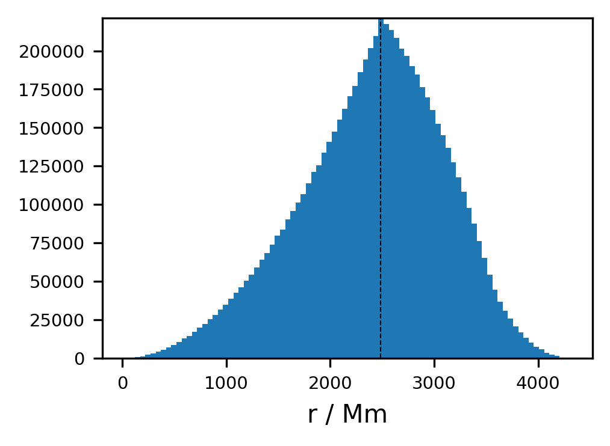

```python
# this ensures that I can open an close the figure that was plotted within this cell.
# It doesn't matter in what order I run the notebook cells, this keeps track of it
celln = 0

# configure plots
close_local = ppm.close_plot(celln,ifig,ptrack)
if close_local[0]:
    plt.close(fig); ifig += 1; fig = plt.figure(ifig,figsize=(3.5,2.5),dpi=300)
    ppm.add_plot(celln,ifig,ptrack)
else:
    ifig += 1; fig = plt.figure(ifig,figsize=(3.5,2.5),dpi=300)
    ppm.add_plot(celln,ifig,ptrack)

# set the colour/linestyle counter to 0 and create axes
cbc = 0
ax = fig.add_subplot(111)

# histogram of radius values
hist_data = ax.hist(r.flatten(),86)

# plot details
xmax = np.max(x)
ylims = [0,np.max(hist_data[0])]
ax.vlines(xmax,*ylims,linestyles='--',lw=0.5)
ax.set_xlabel('r / Mm')
ax.set_ylabel('')
ax.set_ylim(ylims)
```

## Planar slice image

```python
# extent in x,y
extent=[np.min(x),np.max(x),np.min(y),np.max(y)]

# the take a slice at z=0. This is halfway through the indices
slice_num = int(moms_ngridpoints/2)
```

#### Radius

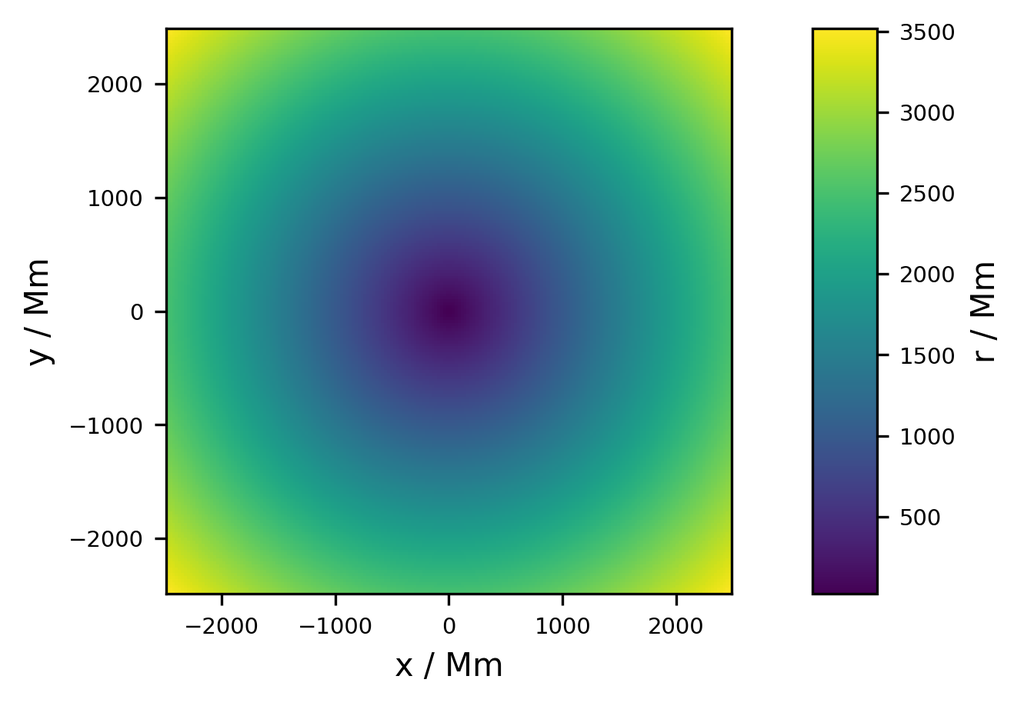

```python
# this ensures that I can open an close the figure that was plotted within this cell.
# It doesn't matter in what order I run the notebook cells, this keeps track of it
celln = 1

# configure plots
close_local = ppm.close_plot(celln,ifig,ptrack)
if close_local[0]:
    plt.close(fig); ifig += 1; fig = plt.figure(ifig,figsize=(3.5,2.5),dpi=300)
    ppm.add_plot(celln,ifig,ptrack)
else:
    ifig += 1; fig = plt.figure(ifig,figsize=(3.5,2.5),dpi=300)
    ppm.add_plot(celln,ifig,ptrack)

# set the colour/linestyle counter to 0 and create axes
cbc = 0
ax = plt.axes([0.01, 0.98, 0.88, 0.98])

ax.imshow(r[:,:,slice_num],extent=extent)

# plot details
ax.set_ylabel('y / Mm')
ax.set_xlabel('x / Mm')

# create a colorbar for the imshow data, use a new axes for it
cax = fig.add_axes([0.90, 0.98, 0.08, 0.98])
cbar1 = fig.colorbar(ax.images[0], cax=cax, orientation='vertical',format='%d',
                     label=r'r / Mm')
```

## $| u_{\perp} |$

We can simply construct the magnitude of the tangential velocity from the cartesian vector velocity components

```python
# get the cartesian velocity components
ux = myhydro.moms.get('ux',fname=mydump)
uy = myhydro.moms.get('uy',fname=mydump)
uz = myhydro.moms.get('uz',fname=mydump)

# convert to spherical components
ur, utheta, uphi = myhydro.moms.get_spherical_components(ux, uy, uz)
u_perp = np.sqrt(np.power(utheta,2.0) + np.power(uphi,2.0))

# store for later, |u|
u_cartesian = myhydro.moms.norm(ux, uy, uz)
u_spherical = myhydro.moms.norm(ur, utheta, uphi)

# they are practically the same
print((u_cartesian - u_spherical).mean(), (u_cartesian - u_spherical).std())
```

```
6.3248967e-14 2.054881e-10
```

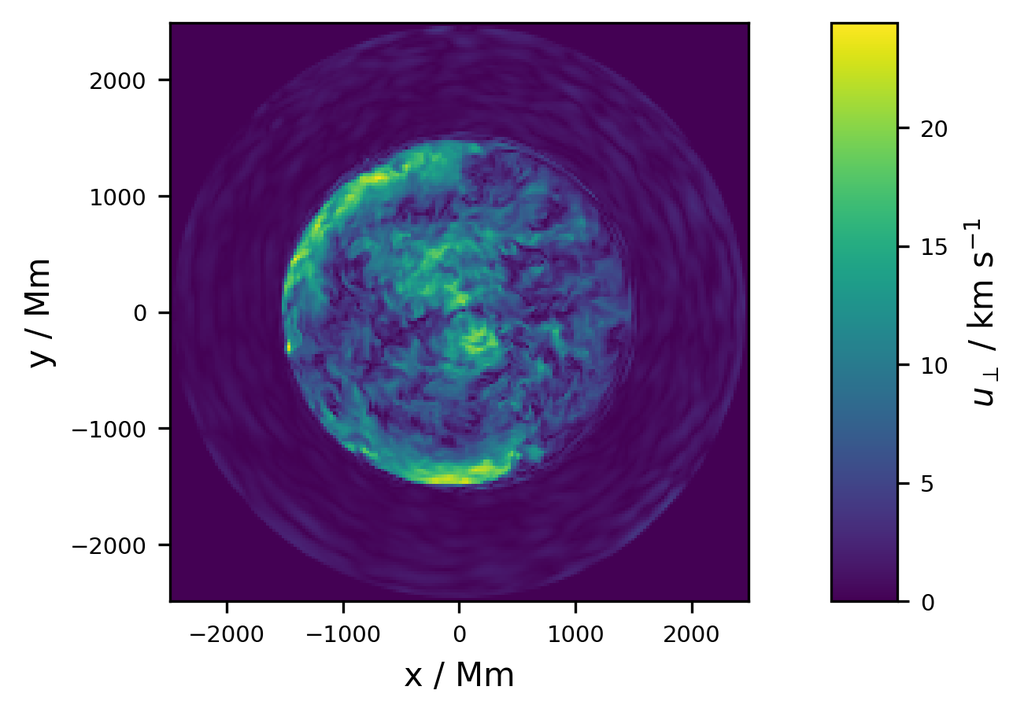

```python
# this ensures that I can open an close the figure that was plotted within this cell.
# It doesn't matter in what order I run the notebook cells, this keeps track of it
celln = 2

# configure plots
close_local = ppm.close_plot(celln,ifig,ptrack)
if close_local[0]:
    plt.close(fig); ifig += 1; fig = plt.figure(ifig,figsize=(3.5,2.5),dpi=300)
    ppm.add_plot(celln,ifig,ptrack)
else:
    ifig += 1; fig = plt.figure(ifig,figsize=(3.5,2.5),dpi=300)
    ppm.add_plot(celln,ifig,ptrack)

# set the colour/linestyle counter to 0 and create axes
cbc = 0
ax = plt.axes([0.01, 0.98, 0.88, 0.98])

# get the tangential velocity and make it km/s rather than Mm/s
ax.imshow(u_perp[:,:,slice_num]*1e3,extent=extent,vmin=0)

# plot details
ax.set_ylabel('y / Mm')
ax.set_xlabel('x / Mm')

# create a colorbar for the imshow data, use a new axes for it
cax = fig.add_axes([0.90, 0.98, 0.08, 0.98])
cbar1 = fig.colorbar(ax.images[0], cax=cax, orientation='vertical',format='%.0f',
                     label=r'$u_{\perp}$ / km s$^{-1}$')
```

## Radial profiles

Radial profiles can be directly taken from the *rprof* data sets. They can also be constructed from the *moms* data. This is demonstrated below.

```python
# for rprofs we will grab the spherical averages directly
T9_rprof = myhydro.rprof.compute_T9(fname=mydump)
R_rprof = myhydro.rprof.get('R',fname=mydump,resolution='l')

# for moments data we will have to use the base components and compute T9
cldmu = myhydro.rprof.get('cldmu',fname=0)
airmu = myhydro.rprof.get('airmu',fname=0)
Rgas = 8.314462

# calculate mu for T
fv = myhydro.moms.get('fv',fname=mydump)
mu = cldmu * fv + (1-fv)*airmu

P = myhydro.moms.get('P',fname=mydump)
rho = myhydro.moms.get('rho',fname=mydump)
T9 = (mu * P) / (Rgas * rho)

# get the radial profile of T
T9_moms, R_moms = myhydro.moms.get_rprof(T9)
```

#### T9

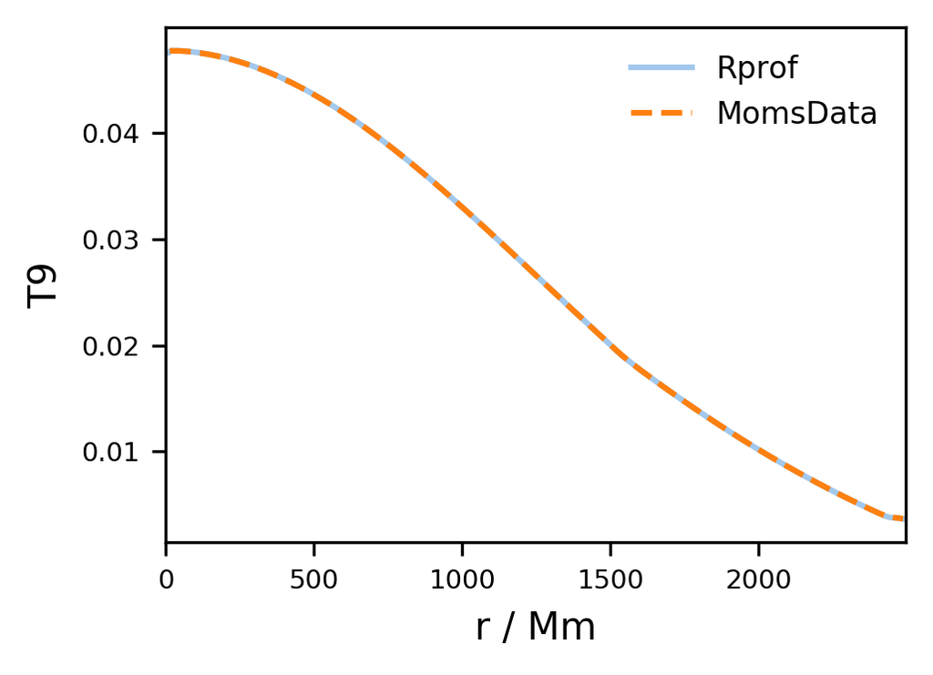

```python
# this ensures that I can open an close the figure that was plotted within this cell.
# It doesn't matter in what order I run the notebook cells, this keeps track of it
celln = 3

# configure plots
close_local = ppm.close_plot(celln,ifig,ptrack)
if close_local[0]:
    plt.close(fig); ifig += 1; fig = plt.figure(ifig,figsize=(3.5,2.5),dpi=300)
    ppm.add_plot(celln,ifig,ptrack)
else:
    ifig += 1; fig = plt.figure(ifig,figsize=(3.5,2.5),dpi=300)
    ppm.add_plot(celln,ifig,ptrack)

# set the colour/linestyle counter to 0 and create axes
cbc = 0
ax = fig.add_subplot(111)

ax.plot(R_rprof, T9_rprof, label='Rprof', color=cb(cbc)[2], ls=cb(cbc)[0])
cbc += 1

ax.plot(R_moms, T9_moms, label='MomsData', color=cb(cbc)[2], ls=cb(cbc)[0])
cbc += 1

# plot details
ax.set_ylabel('T9')
ax.set_xlabel('r / Mm')
ax.set_xlim([0, R_rprof.max()])

ax.legend(frameon=False,fontsize=8)
```

#### |u|

```python
U_rprof = myhydro.rprof.get('|U|',fname=mydump)

# we computed |U| from the cartesian components of U as well as spherical and they are the same on the
# entire grid. Use cartesian
U_moms, R_moms = myhydro.moms.get_rprof(u_cartesian)
```

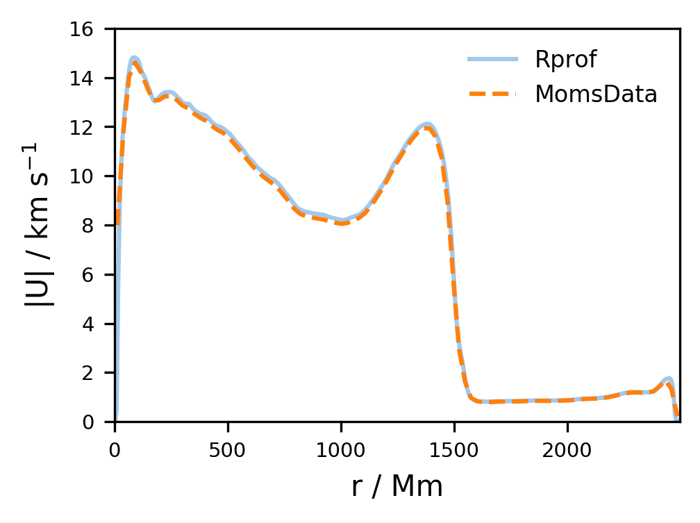

```python
# this ensures that I can open an close the figure that was plotted within this cell.
# It doesn't matter in what order I run the notebook cells, this keeps track of it
celln = 4

# configure plots
close_local = ppm.close_plot(celln,ifig,ptrack)
if close_local[0]:
    plt.close(fig); ifig += 1; fig = plt.figure(ifig,figsize=(3.5,2.5),dpi=300)
    ppm.add_plot(celln,ifig,ptrack)
else:
    ifig += 1; fig = plt.figure(ifig,figsize=(3.5,2.5),dpi=300)
    ppm.add_plot(celln,ifig,ptrack)

# set the colour/linestyle counter to 0 and create axes
cbc = 0
ax = fig.add_subplot(111)

# convert to km/s
ax.plot(R_rprof, U_rprof*1e3, label='Rprof', color=cb(cbc)[2], ls=cb(cbc)[0])
cbc += 1

ax.plot(R_moms, U_moms*1e3, label='MomsData', color=cb(cbc)[2], ls=cb(cbc)[0])
cbc += 1

# plot details
ax.set_ylabel('|U| / km s$^{-1}$')
ax.set_xlabel('r / Mm')
ax.set_xlim([0, R_rprof.max()])
ax.set_ylim([0,16])

ax.legend(frameon=False,fontsize=8)
```